```r
#Q1
library(png)
library(dplyr)
library(scales)
library(reshape2)
library(class)
library(e1071)
library(caret)
library(ROCR)
path <- "C:/Users/simpl/OneDrive/桌面/111_下學期/資料分析方法/HW02/ORL Faces/ORL Faces"

data <- data.frame(matrix(nrow = 0, ncol = 2576),row.names = character())

for (i in 1:40) {
  for(j in 1:10){
    file <- file.path(path, paste0( i,"_",j,".png"))
    img <- readPNG(file)
    vec <- as.vector(img)
    data <- rbind(data, vec)
  }
}
gender<-c(rep(0,10),rep(1,10),rep(1,10),rep(1,10),rep(1,10),rep(1,10),rep(1,10),rep(0,10),rep(1,10),rep(0,10),
          rep(1,10),rep(1,10),rep(1,10),rep(1,10),rep(1,10),rep(1,10),rep(1,10),rep(1,10),rep(1,10),rep(1,10),
          rep(1,10),rep(1,10),rep(1,10),rep(1,10),rep(1,10),rep(1,10),rep(1,10),rep(1,10),rep(1,10),rep(1,10),
          rep(1,10),rep(0,10),rep(1,10),rep(1,10),rep(1,10),rep(1,10),rep(1,10),rep(1,10),rep(1,10),rep(1,10))
names(data) <- paste0("Pixel", 1:2576)

data_with_label <- cbind(data, gender)
y<-data_with_label[,2577]

set.seed(123)

trainIndex<-sample(1:nrow(data),0.7*nrow(data))
train_data<-data_with_label[trainIndex,]
test_data<-data_with_label[-trainIndex,]
test_X<-test_data[,1:2576]
test_Y<-test_data[,2577]

logi_model<- glm(gender~.,family="binomial",data=train_data)
logi_pred<- predict(logi_model,newdata = test_X)
logi_pred<-ifelse(logi_pred>0.5,1,0)
logi_ACC<-sum(logi_pred==test_Y)/length(test_Y)
logi_confusionMatrix<-confusionMatrix(table(logi_pred,test_Y))
prediction_obj<-prediction(logi_pred,test_Y)
logi_performance_obj<-performance(prediction_obj,"tpr","fpr")
logi_auc_obj<-performance(prediction_obj,"auc")
logi_auc_value<-logi_auc_obj@y.values[[1]]


knn_pred<-knn(train=train_data[,1:2576],test=test_X,cl=train_data[,2577],k=5)
knn_confusionMatrix<-confusionMatrix(table(knn_pred,test_Y))
knn_ACC<-sum(knn_pred==test_Y)/length(test_Y)
knn_pred<-as.numeric(knn_pred)
prediction_obj<-prediction(knn_pred,test_Y)
knn_performance_obj<-performance(prediction_obj,"tpr","fpr")
knn_auc_obj<-performance(prediction_obj,"auc")
knn_auc_value<-knn_auc_obj@y.values[[1]]


svm_model<-svm(gender~.,data=train_data)
svm_pred<-predict(svm_model,newdata = test_X)
svm_pred<-ifelse(svm_pred>0.5,1,0)
svm_ACC<-sum(svm_pred==test_Y)/length(test_Y)
svm_confusionMatrix<-confusionMatrix(table(svm_pred,test_Y))
prediction_obj<-prediction(svm_pred,test_Y)
svm_performance_obj<-performance(prediction_obj,"tpr","fpr")
svm_auc_obj<-performance(prediction_obj,"auc")
svm_auc_value<-svm_auc_obj@y.values[[1]]

logi_confusionMatrix$byClass
```

```
##          Sensitivity          Specificity       Pos Pred Value
##            0.4615385            0.5607477            0.1132075
##       Neg Pred Value            Precision               Recall
##            0.8955224            0.1132075            0.4615385
##                   F1           Prevalence       Detection Rate
##            0.1818182            0.1083333            0.0500000
## Detection Prevalence    Balanced Accuracy
##            0.4416667            0.5111431
```

```r
knn_confusionMatrix$byClass
```

```
##          Sensitivity          Specificity       Pos Pred Value
##           0.76923077           1.00000000           1.00000000
##       Neg Pred Value            Precision               Recall
##           0.97272727           1.00000000           0.76923077
##                   F1           Prevalence       Detection Rate
##           0.86956522           0.10833333           0.08333333
## Detection Prevalence    Balanced Accuracy
##           0.08333333           0.88461538
```

```r
svm_confusionMatrix$byClass
```

```
##          Sensitivity          Specificity       Pos Pred Value
##           0.53846154           1.00000000           1.00000000
##       Neg Pred Value            Precision               Recall
##           0.94690265           1.00000000           0.53846154
##                   F1           Prevalence       Detection Rate
##           0.70000000           0.10833333           0.05833333
## Detection Prevalence    Balanced Accuracy
##           0.05833333           0.76923077
```

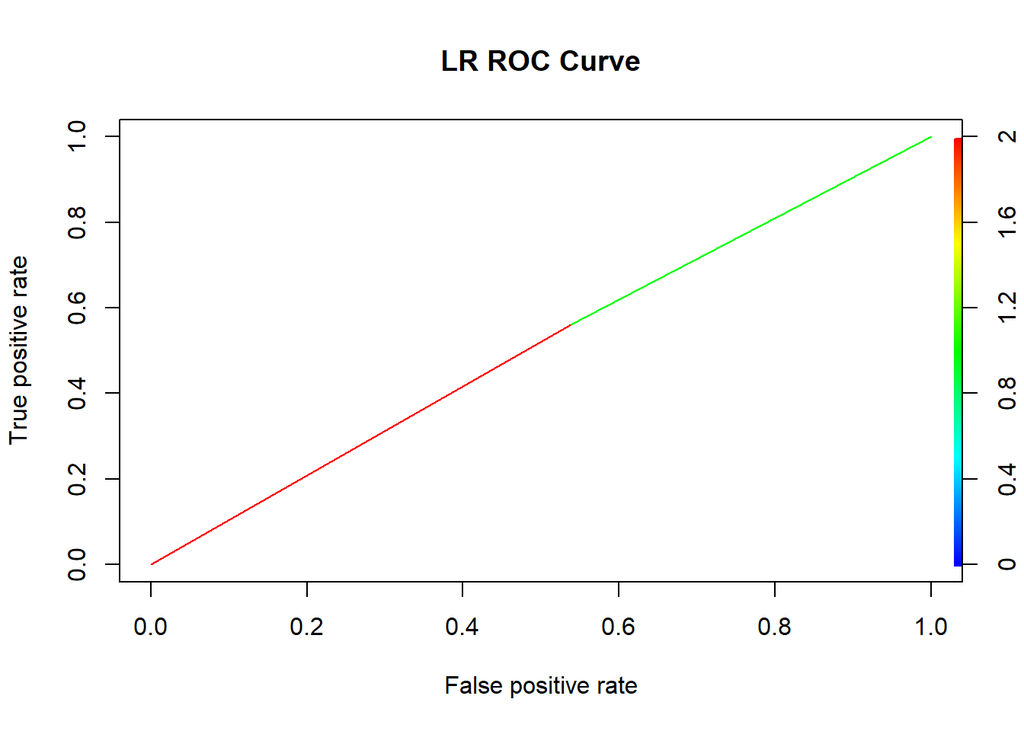

```r
plot(logi_performance_obj,main="LR ROC Curve",colorize=TRUE)
```

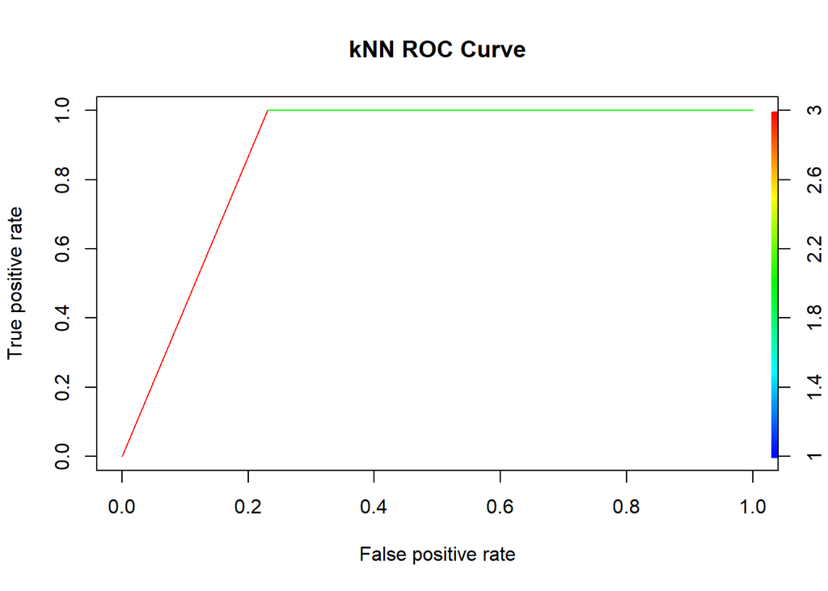

```r
plot(knn_performance_obj,main="kNN ROC Curve",colorize=TRUE)
```

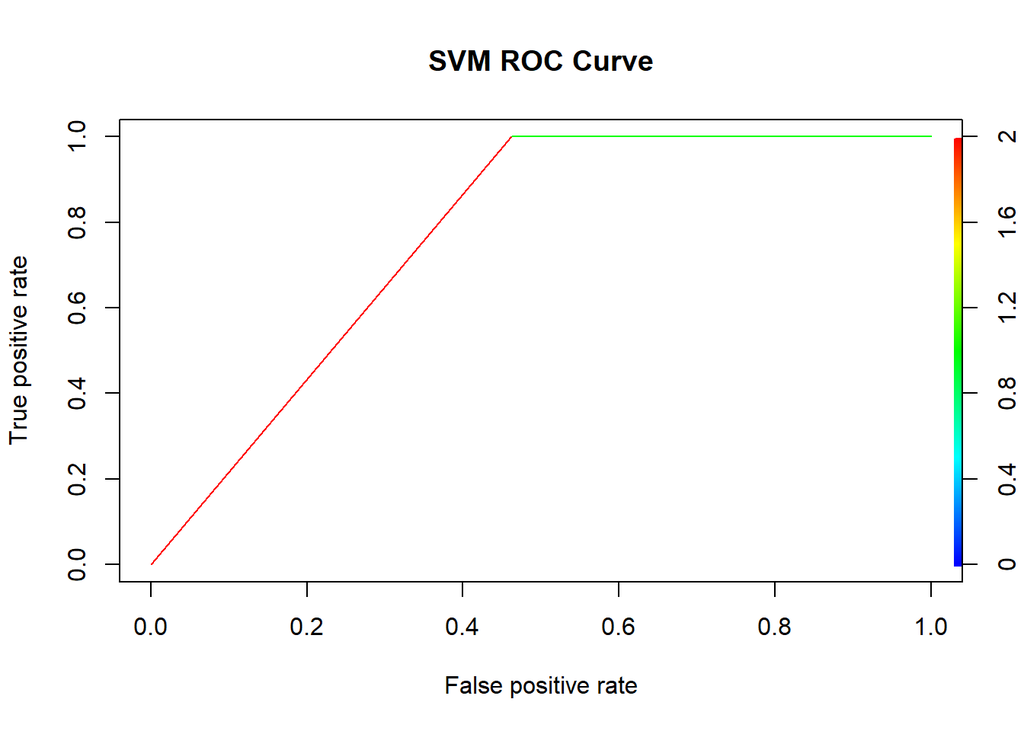

```r
plot(svm_performance_obj,main="SVM ROC Curve",colorize=TRUE)
```

```r
cat("LR AUC:", logi_auc_value, "\nkNN AUC:", knn_auc_value, "\nSVM AUC:", svm_auc_value)
```

```
## LR AUC: 0.5111431
## kNN AUC: 0.8846154
## SVM AUC: 0.7692308
```

```r
cat("LR accuracy:",round(logi_ACC,2),"\nkNN accuracy",round(knn_ACC,2),"\nSVM accuracy",round(svm_ACC,2))
```

```
## LR accuracy: 0.55
## kNN accuracy 0.98
## SVM accuracy 0.95
```

We can evaluate the performance of a model based on different criteria, such as AUC and accuracy. From the results above, it can be seen that the accuracy of the kNN and SVM models is quite good. However, the Sensitivity shows that the performance of the LR and SVM models is not as good as that of the kNN model. Overall, I would choose to use either the kNN or SVM model, both of which have different classification method, to fit this ORL data set.

Q2.

```r
library(glmnet)
data<-as.matrix(data)
gender<-as.matrix(gender)
cv_model <- cv.glmnet(data,gender,alpha=1)
best_lambda <- cv_model$lambda.min
lasso_model <- glmnet(data,gender,alpha = 1,lambda = best_lambda)
coef<-coef(lasso_model)

chosen_pixels<-c()
for (i in 1:nrow(coef)){
  if (coef[i, ] != 0){
    chosen_pixels<-rbind(chosen_pixels,i)
  }
}
chosen_pixels_index<-chosen_pixels[,1]
new_data<-as.data.frame(data[,chosen_pixels_index])
new_data_with_label<-cbind(new_data, gender)
set.seed(123)

trainIndex<-sample(1:nrow(new_data),0.7*nrow(new_data))
train_data<-new_data_with_label[trainIndex,]
test_data<-new_data_with_label[-trainIndex,]
ncol(test_data)
```

```
## [1] 253
```

```r
test_X<-test_data[,1:ncol(test_data)-1]
test_Y<-test_data[,ncol(test_data)]

logi_model<- glm(gender~.,family="binomial",data=train_data)
logi_pred<- predict(logi_model,newdata = test_X)
logi_pred<-ifelse(logi_pred>0.5,1,0)
logi_ACC<-sum(logi_pred==test_Y)/length(test_Y)

knn_pred<-knn(train=train_data[,1:ncol(test_data)-1],test=test_X,cl=train_data[,ncol(test_data)],k=5)
knn_ACC<-sum(knn_pred==test_Y)/length(test_Y)

svm_model<-svm(gender~.,data=train_data)
svm_pred<-predict(svm_model,newdata = test_X)
svm_pred<-ifelse(svm_pred>0.5,1,0)
svm_ACC<-sum(svm_pred==test_Y)/length(test_Y)

cat("LR accuracy:",round(logi_ACC,2),"\nkNN accuracy",round(knn_ACC,2),"\nSVM accuracy",round(svm_ACC,2))
```

```
## LR accuracy: 0.88
## kNN accuracy 0.97
## SVM accuracy 0.96
```

Q3.

```r
library(pROC)
setwd("C:/Users/simpl/OneDrive/桌面/111_下學期/資料分析方法/HW03")
data <- read.table("auto-mpg.data.txt",header = FALSE,sep = "")
str(data)
```

```
## 'data.frame':    398 obs. of  9 variables:
##  $ V1: num  18 15 18 16 17 15 14 14 14 15 ...
##  $ V2: int  8 8 8 8 8 8 8 8 8 8 ...
##  $ V3: num  307 350 318 304 302 429 454 440 455 390 ...
##  $ V4: chr  "130.0" "165.0" "150.0" "150.0" ...
##  $ V5: num  3504 3693 3436 3433 3449 ...
##  $ V6: num  12 11.5 11 12 10.5 10 9 8.5 10 8.5 ...
##  $ V7: int  70 70 70 70 70 70 70 70 70 70 ...
##  $ V8: int  1 1 1 1 1 1 1 1 1 1 ...
##  $ V9: chr  "chevrolet chevelle malibu" "buick skylark 320" "plymouth satellite" "amc rebel sst" ...
```

```r
colnames(data) <- c("mpg","cylinders","displacement","horsepower","weight","acceleration","model_year","origin","car name")

data_withoutcarname<-subset(data,select=c(1:(ncol(data)-1)))
data_withoutcarname$horsepower <- as.numeric(data_withoutcarname$horsepower)

x<-na.omit(data_withoutcarname)

library(nnet)

trainIndex<-sample(1:nrow(x),0.7*nrow(x))
train_data<-x[trainIndex,]
test_data<-x[-trainIndex,]
test_X<-test_data[,1:7]
test_Y<-test_data[,8]

logi_model<- multinom(origin ~ ., data = train_data)
```

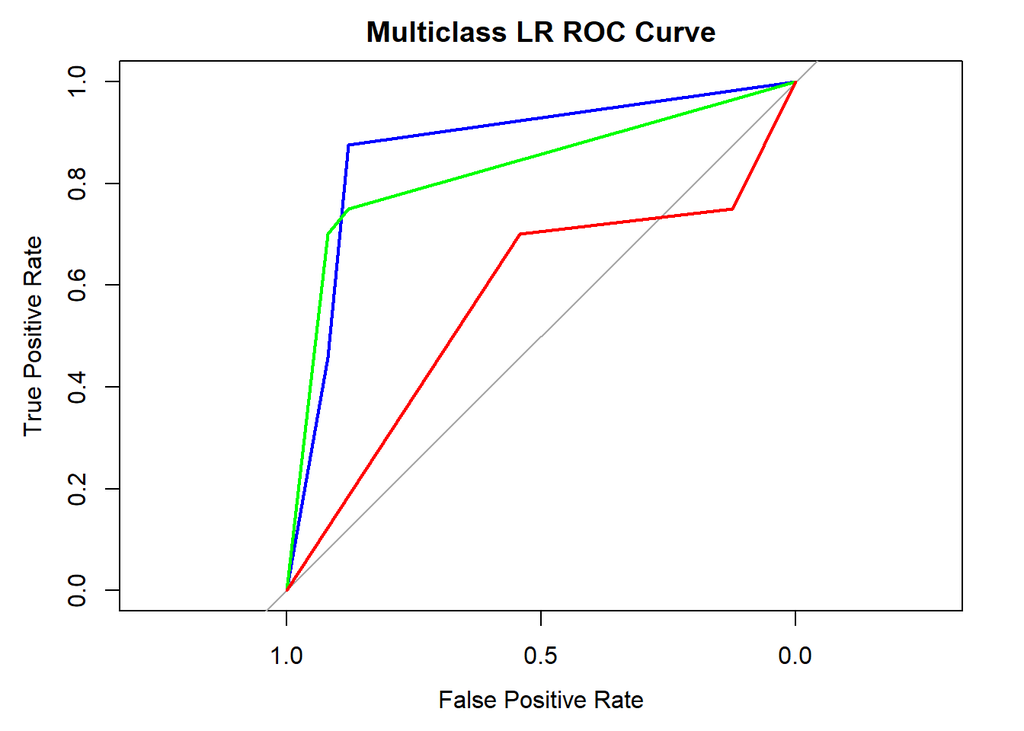

```r
logi_pred<- predict(logi_model,newdata = test_X)
logi_ACC<-sum(logi_pred==test_Y)/length(test_Y)
logi_pred<-as.numeric(logi_pred)
logi_roc<-multiclass.roc(test_Y,logi_pred,plot=FALSE)


knn_pred<-knn(train=train_data[,1:7],test=test_X,cl=train_data[,8],k=5)
knn_ACC<-sum(knn_pred==test_Y)/length(test_Y)
knn_pred<-as.numeric(knn_pred)
knn_roc<-multiclass.roc(test_Y,knn_pred,plot=FALSE)


svm_model<-svm(origin~.,data=train_data,type="C-classification",decision.values = TRUE)
svm_pred<-predict(svm_model,newdata = test_X)
svm_ACC<-sum(svm_pred==test_Y)/length(test_Y)
svm_pred<-as.numeric(svm_pred)
svm_roc<-multiclass.roc(test_Y,svm_pred,plot=FALSE)


plot(logi_roc$rocs[[1]],type="l",col="blue",main="Multiclass LR ROC Curve",xlab = "False Positive Rate", ylab = "True Positive Rate")
lines(logi_roc$rocs[[2]],type="l",col="green")
lines(logi_roc$rocs[[3]],type="l",col="red")
```

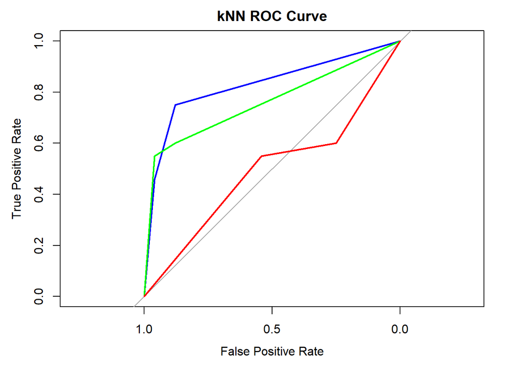

```r
plot(knn_roc$rocs[[1]],type="l",col="blue",main="kNN ROC Curve",xlab = "False Positive Rate", ylab = "True Positive Rate")
lines(knn_roc$rocs[[2]],type="l",col="green")
lines(knn_roc$rocs[[3]],type="l",col="red")
```

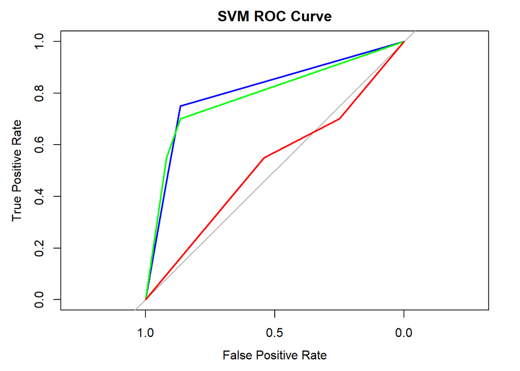

```r
plot(svm_roc$rocs[[1]],type="l",col="blue",main="SVM ROC Curve",xlab = "False Positive Rate", ylab = "True Positive Rate")
lines(svm_roc$rocs[[2]],type="l",col="green")
lines(svm_roc$rocs[[3]],type="l",col="red")
```

```r
cat("Multiclass LR AUC:", logi_roc$auc, "\nkNN AUC:", knn_roc$auc, "\nSVM AUC:", svm_roc$auc)
```

```
## Multiclass LR AUC: 0.7557714
## kNN AUC: 0.6936937
## SVM AUC: 0.7066817
```

```r
cat("Multiclass LR accuracy:",round(logi_ACC,2),"\nkNN accuracy",round(knn_ACC,2),"\nSVM accuracy",round(svm_ACC,2))
```

```
## Multiclass LR accuracy: 0.75
## kNN accuracy 0.7
## SVM accuracy 0.69
```

From the results above, we can compare the accuracy and auc of three different methods. We obtained the similar results in multiclass LR, kNN and SVM. Therefore, we can use multiclass LR, kNN and SVM to model this AutoMPG dataset.